# 4. {ggplot2} (basic)

## 6.3 Coordinate System

| **Elements** | **`{package}:function()`** | **What you can do** |
| --- | --- | --- |
| **3. Coordinate System** | `coord_*()` | Customize the outlook of coordinate system |

#### `coord_()` has the following variations

| **`coord_flip()`** | Exchange `x-axis` and `y-axis` |
| --- | --- |
| **`coord_cartesian()`** | Enlarge and shrink `axes` |
| **`coord_fixed()`** | Fix `axes` |

### 6.3.1 `coord_flip()`: Exchange `x-axis` and `y-axis`

- Let’s show math test scores by `gender` using boxplot
- You use an geometric object, `geom_box()`

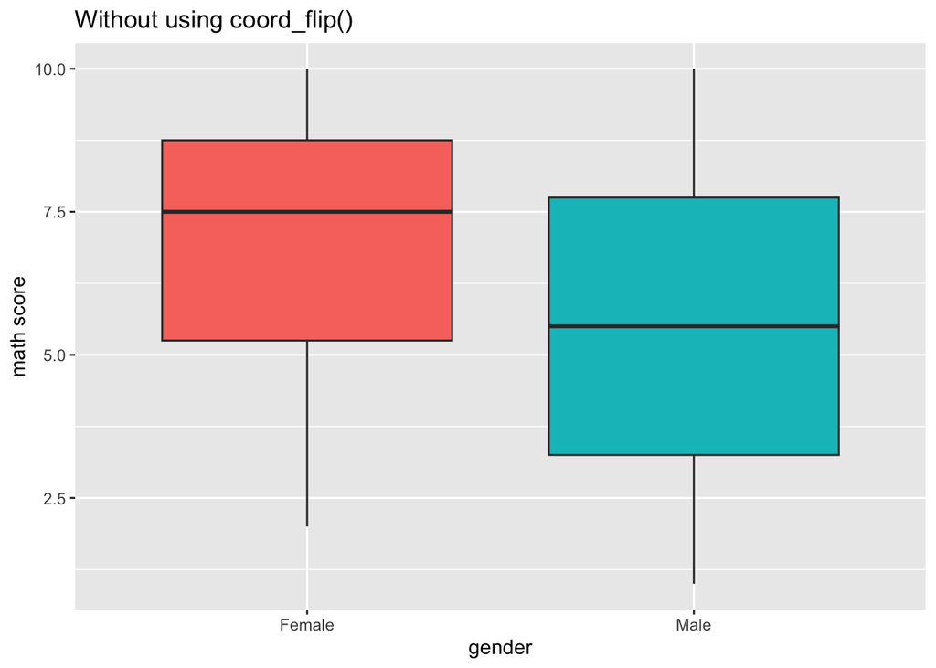

```r
plt_4 <- df1  %>%
  ggplot() +
  geom_boxplot(aes(x = gender,
y = math,
fill = gender),
 show.legend = FALSE) +
  labs(x = "gender", y = "math score") +
  ggtitle("Without using coord_flip()")

plt_4
```

- Exchange `x-axis` and `y-axis` by using `coord_flip()`

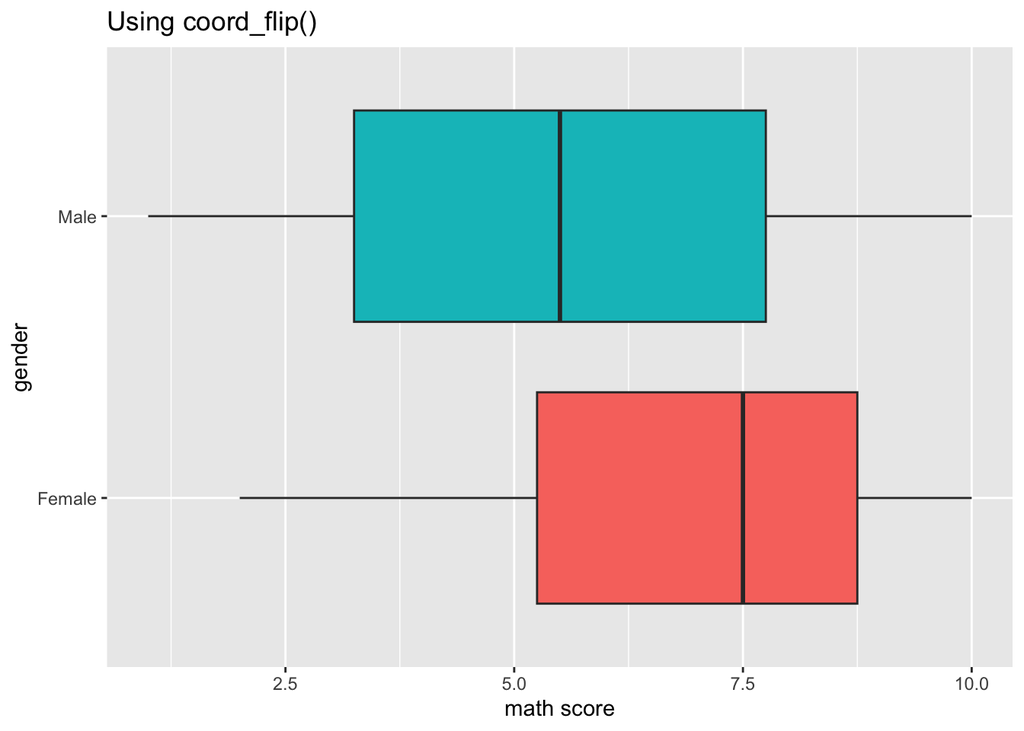

```r
plt_5 <- df1  %>%
  ggplot() +
  geom_boxplot(aes(x = gender,
y = math,
fill = gender),
 show.legend = FALSE) +
  labs(x = "gender", y = "math score") +
  ggtitle("Using coord_flip()") +
  coord_flip()  # Exchange axes

plt_5
```

- Using `{patchwork}`, let’s show the two graphs in one row

```r
library(patchwork)
```

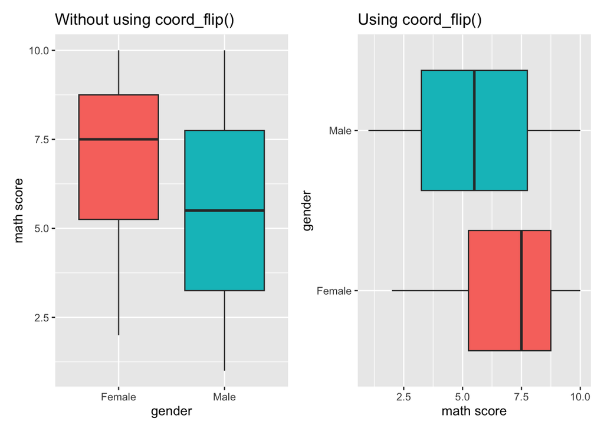

```r
plt_4 + plt_5
```

### 6.3.2 `coord_cartesian()`

- You use `coord_cartesian()` when you enlarge and shrink axes

```r
hr <- read_csv("data/hr96-26.csv", na = ".")
```

- Use the 2005 election data and name the data frame, `hr2005`

```r
hr2005 <- hr %>%
  filter(year == 2005)
```

- Represent the relationship between exp and vote share using a curb line

```r
plt_6 <- hr2005 %>%
  ggplot() +
  aes(exp, voteshare) +
  geom_point() +
  geom_smooth(se=FALSE) + # Hide the 95 confidence level
  theme_bw()
```

- Show the all range

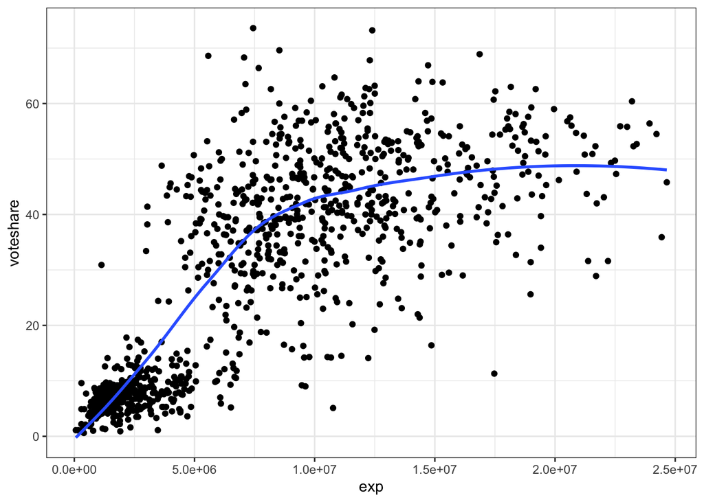

```r
plt_6
```

#### Using `coord_cartesian()`, you can limit the range of output

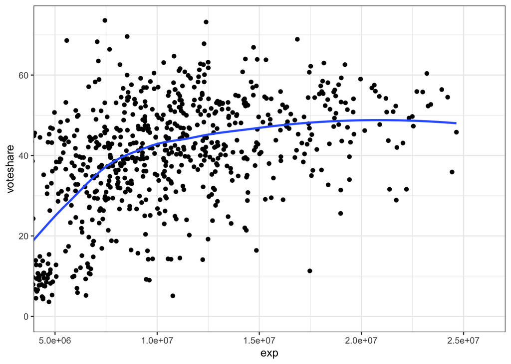

```r
plt_6 +
  coord_cartesian(xlim = c(5.0e+6, 2.6e+07))
```

#### Using `xlim()`, you can limit the range of output

```r
plt_6 +
  xlim(5.0e+6, 2.6e+07)
```

```
Warning: Removed 353 rows containing non-finite outside the scale range
(`stat_smooth()`).
```

```
Warning: Removed 353 rows containing missing values or values outside the scale range
(`geom_point()`).
```

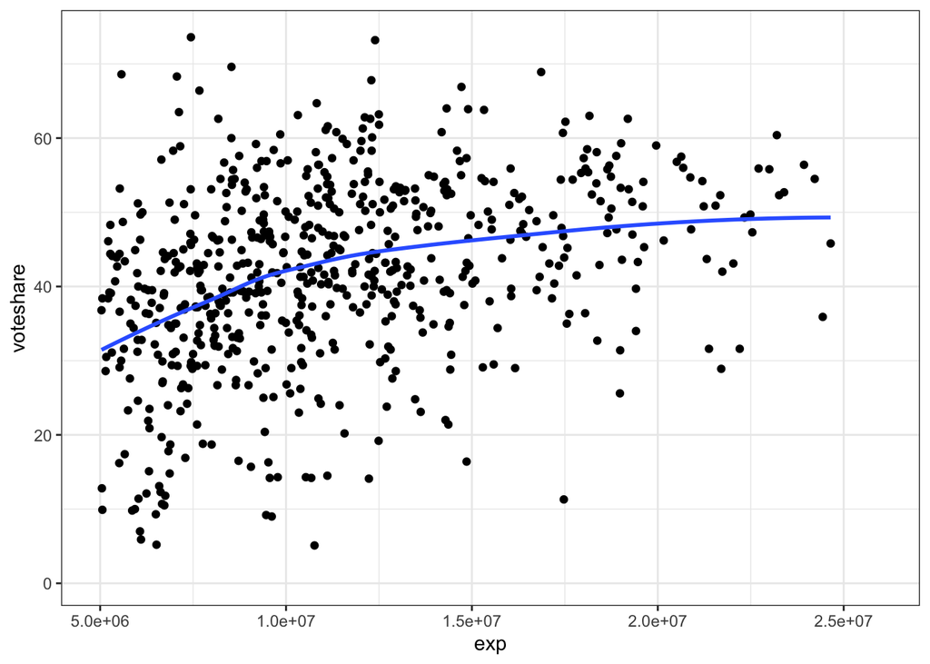

**・We see the two warnings: “Removed 353 rows containing non-finite values (stat_smooth)” & “Removed 353 rows containing missing values (geom_point)”**

Why we should use `coord_cartesian()` ・ If you use `xlim()`, then R treats the data out of the range as missing data (`NA`)  
→ You see a different graph generated with the original data  
→ **If you just want to “enlarge” a certain part of a graph, you should use `coord_cartesian()` instead of `xlim`**

### 6.3.3 `coord_fixed()`

- You use `coord_fixed()` when you want to fix `axes`
- Let’s draw a scatter plot with a fake data

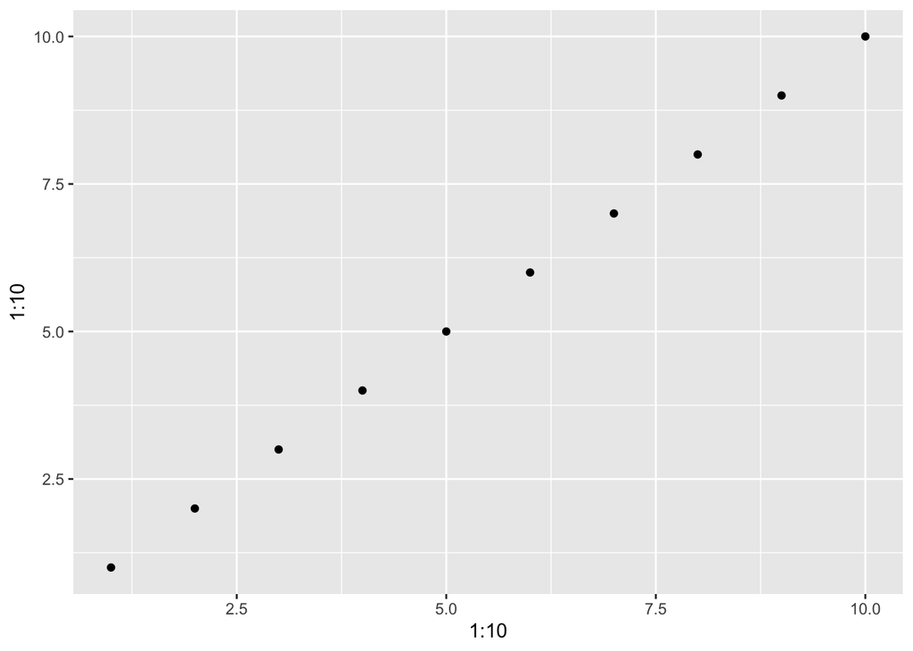

```r
ggplot() +
  geom_point(aes(x = 1:10,
   y = 1:10))
```

- Using `coord_fixed()`, let’s assign the ratio of `x:y = 1:2`

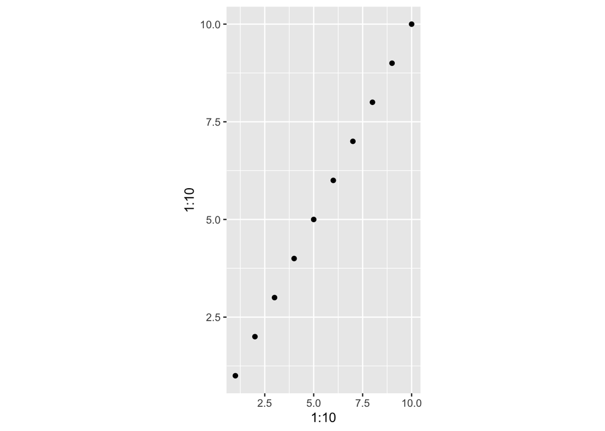

```r
ggplot() +
  geom_point(aes(x = 1:10,
   y = 1:10)) +
  coord_fixed(ratio = 2)
```

- Originally, `x` and `y` are exactly the same
- But, `y` looks larger than `x`
- Let’s type `coord_fixed(ratio = 1)`

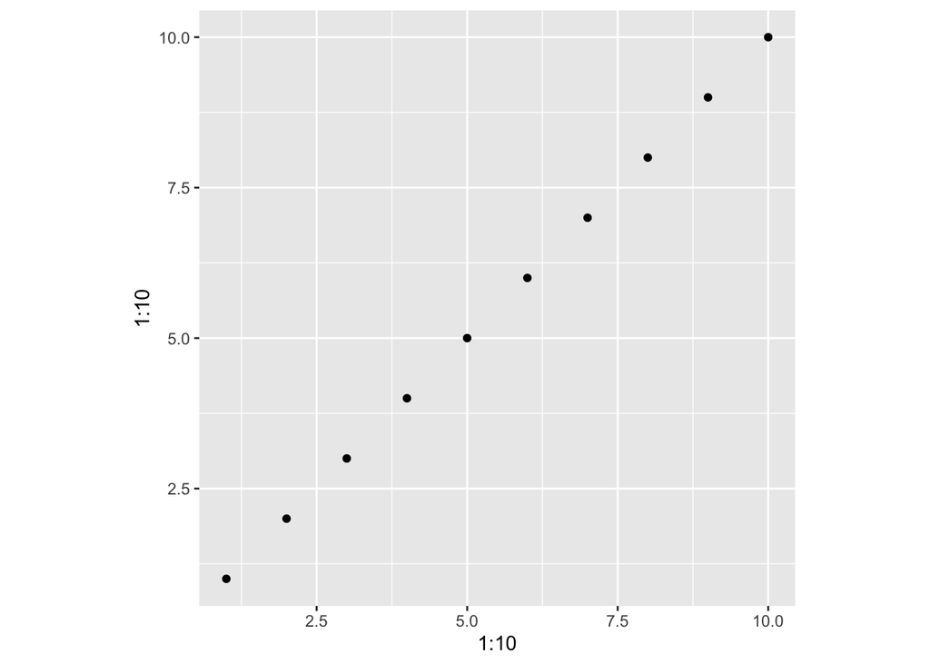

```r
ggplot() +
  geom_point(aes(x = 1:10,
   y = 1:10)) +
  coord_fixed(ratio = 1)
```

## 6.4 統計処理

| **Elements** | **`{package}:function()`** | **What you can do** |
| --- | --- | --- |
| **4. 統計処理** | `stat_*()` | Statistical Treatment |

- Let’s draw a bar chart of the number of candidates running in the 2021 lower house election in Japan using `geom_bar()`

#### **`geom_bar(stat = "count")`**

→ Map `seito` like `aes(x = seito)` and the number of party candidates and display it on `y-axis`  
- You don’t have to map `y`  
→ `stat = "count"` is applied in `group`  
→ The number of party candidates is calculated → Displayed in `y-axis`

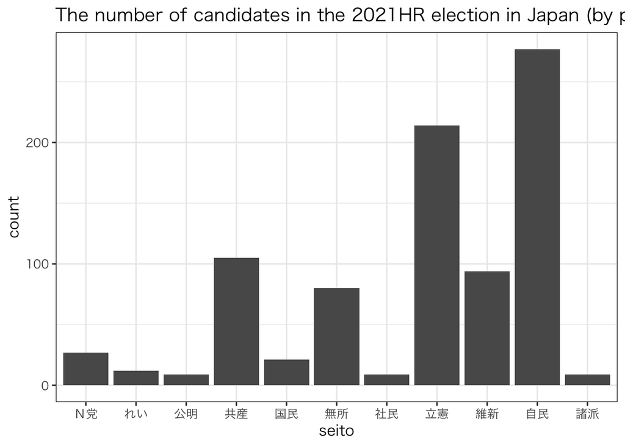

```r
hr %>%
  filter(year == 2021) %>%
  ggplot(aes(x = seito)) +
  geom_bar(stat = "count") +
  theme_bw(base_family = "HiraKakuProN-W3", # You need to add this layer because party name is written in Japanese
   base_size = 12) +
  ggtitle("The number of candidates in the 2021HR election in Japan (by party")
```

- Let’s make a double check about whether the number of candidates by party is correct in the 2021 HR election by using `group_by()`

```r
hr %>%
  filter(year == 2021) %>%
  group_by(seito) %>%
  summarize(N = n())
```

```
# A tibble: 11 × 2
   seito     N
   <chr> <int>
 1 れい     12
 2 公明      9
 3 共産    105
 4 国民     21
 5 無所     80
 6 社民      9
 7 立憲    214
 8 維新     94
 9 自民    277
10 諸派      9
11 Ｎ党     27
```

#### **geom_bar(stat = “identity”)**

→ This argument enables us to calculate the total number of candidates’ previous wins (`previous`) by party

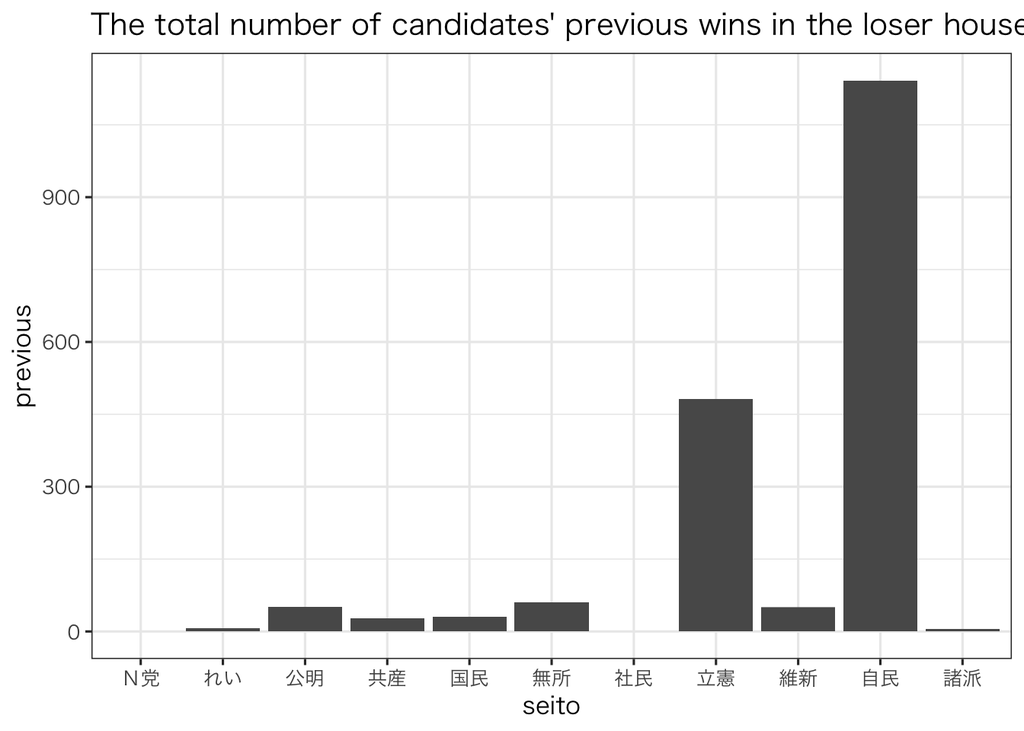

```r
hr %>%
  filter(year == 2021) %>%
  ggplot(aes(x = seito, y = previous)) +
  geom_bar(stat = "identity") +
  theme_bw(base_family = "HiraKakuProN-W3", # You need to add this layer because party name is written in Japanese
   base_size = 12) +
  ggtitle("The total number of candidates' previous wins in the loser house elections (1996-2017) in Japan (by party")
```

- Let’s make a double check about whether the total number of candidates’ previous wins by party using `group_by()`

```r
hr %>%
  filter(year == 2021) %>%
  group_by(seito) %>%
  summarize(sum(previous))
```

```
# A tibble: 11 × 2
   seito `sum(previous)`
   <chr>           <dbl>
 1 れい                6
 2 公明               51
 3 共産               28
 4 国民               30
 5 無所               60
 6 社民                0
 7 立憲              481
 8 維新               50
 9 自民             1142
10 諸派                5
11 Ｎ党                0
```

- For details on bar chart, see[5. ggplot2 (Barchart)](http://asanoucla.github.io/R05_ggplot2_barchart.html)

## 6.5 Scale

- `scale_*()_` enables us to change the colors and shapes of dots
- `{ggplot2}` has various geometric objects
- You can draw various kinds of graphs by using these various geometric objects
- For example, in drawing a scatter plot, data is interpreted as a `dot`
- In drawing a line graph, data is interpreted as a `line`
- In drawing a bar chart and histogram, data is interpreted as a `face`
- The information these `dot`, `line`, and `face` have is called **`scale`**
- We use `scale_*()_` when we need different colors or shapes which is different from the default of `{ggplot2}`

| **Elements** | **`{package}:function()`** | **What you can do** |
| --- | --- | --- |
| **5. Scale** | `scale_*()` | Customize glaph’s colors and shapes |

#### List of `Scale_*()`

| **`scale_x_continuous()`** | Customize the scale of `x-axis`（**continuous variable**） |
| --- | --- |
| **`scale_y_discrete()`** | Customize the scale of `y-axis`（**discrete variable**） |
| **`scale_color_manual()`** | Customize the colors and shapes |

#### The major reasons why you customize the scale of axes

1. You want to change axes
2. You want to change the label of axes

### 6.5.1 Changing axes of continuous variables

#### `scale_*_continuous()`

- When **a continuous variable** is mapped
- You add `scale_*_continuous()` as a new layer
- `*` can be either `x` or `y`
- Let’s draw a scatter plot using the 2005 HR election data:

・`x-axis` ・・・ expenditure (`exp`)  
・`y-axis` ・・・ vote share (`voteshare`)

```r
hr <- read_csv("data/hr96-26.csv", na = ".")
```

- Draw a scatter plot and save it as `plt_money_vs`

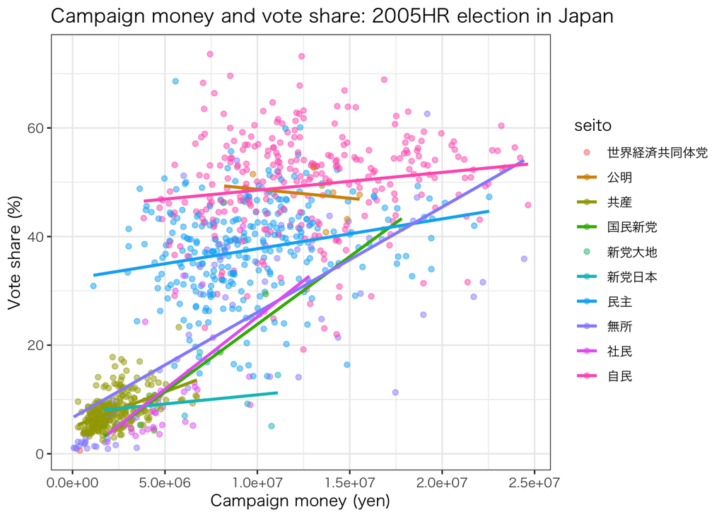

```r
plt_7 <- hr %>%
  select(seito, exp, voteshare, year) %>%
  filter(year == 2005) %>%
  ggplot(aes(x = exp,
y = voteshare,
col = seito)) +
  geom_point(alpha = 0.5) +
  labs(x = "Campaign money (yen)",
  y = "Vote share (%)",
  title = "Campaign money and vote share: 2005HR election in Japan") +
  geom_smooth(method = lm, se = FALSE) +
  theme_bw(base_family = "HiraKakuProN-W3")

plt_7
```

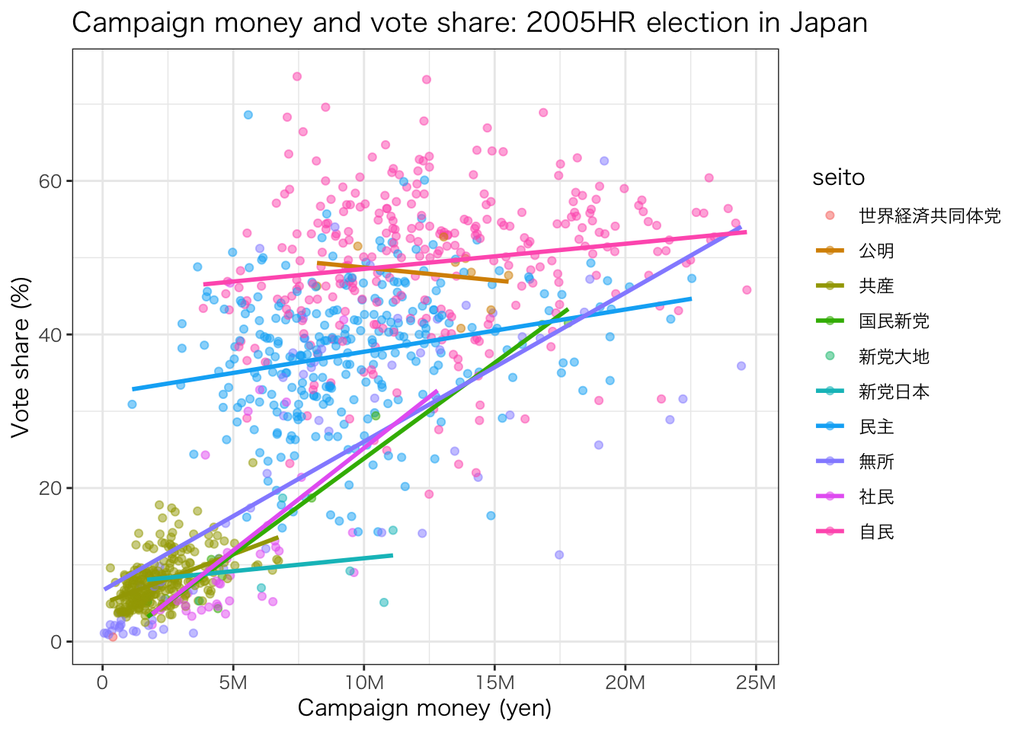

```r
plt_7 +
  scale_x_continuous(breaks = seq(0, 2.5e+07, by = 0.5e+07),
  labels = c("0", "5M", "10M", "15M", "20M", "25M"))
```

#### If you want to change the scale of y-axis…

- You can use `scale_*_continuous()` and set `limits` as an argument
- For instance, suppose you want to limit the range of `y-axis` between 0 and 60  
  → Add `scale_y_continuous(limits = c(0, 60))`

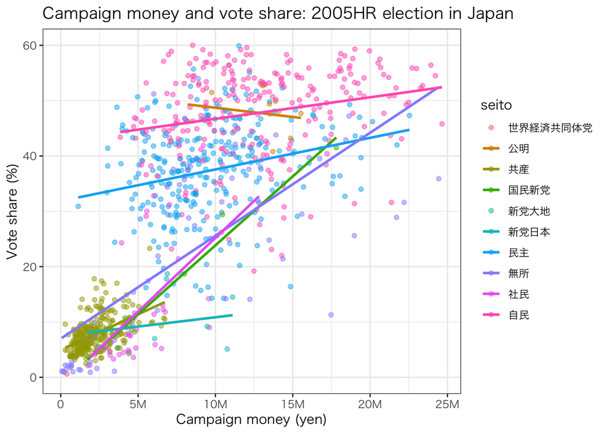

```r
plt_7 +
  scale_x_continuous(breaks = seq(0, 2.5e+07, by = 0.5e+07),
  labels = c("0", "5M", "10M", "15M", "20M", "25M")) +
  scale_y_continuous(limits = c(0, 60))
```

#### How to change the loacation of the scale label

- You can move the the postion of the scale label to the right: `scale_y_continuous(position = "right")`
- You can move the the location of the legend to the left: `theme(legend.position = "left")`

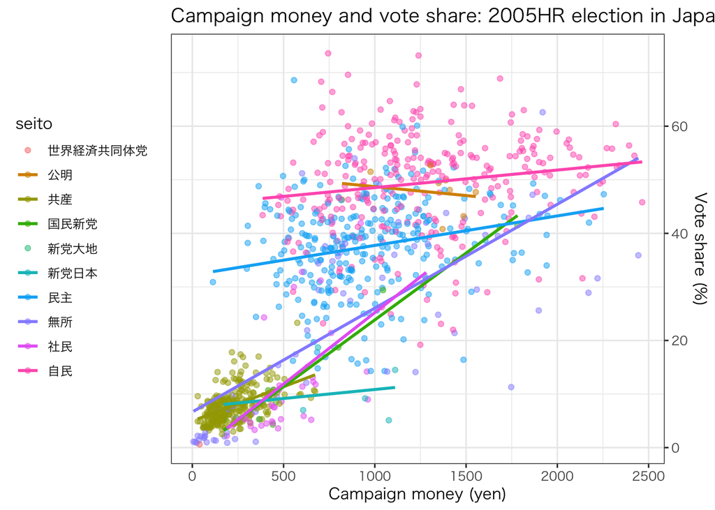

```r
plt_7 +
  scale_x_continuous(breaks = seq(0, 2.5e+07, by = 0.5e+07),
  labels = c(0, 500, 1000, 1500, 2000, 2500)) +
  scale_y_continuous(limits = c(0, 60)) +
  scale_y_continuous(position = "right") +
  theme(legend.position = "left")
```

### 6.5.2 Customize the scale (discrete variables)

#### `scale_*_discrete()`

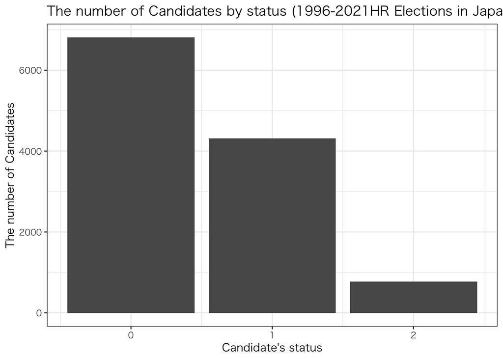

```r
plt_8 <- hr %>%
  ggplot() +
  geom_bar(aes(x = status)) +
  labs(x = "Candidate's status", y = "The number of Candidates") +
  ggtitle("The number of Candidates by status (1996-2021HR Elections in Japan)") +
  theme_bw(base_family = "HiraKakuProN-W3")

plt_8
```

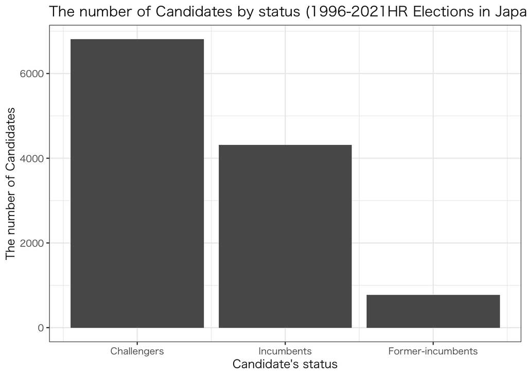

```r
plt_8 +
  scale_x_continuous(breaks = c(0, 1, 2),
  labels = c("Challengers", "Incumbents", "Former-incumbents"))
```

### 6.5.3 Customize the color of dots

#### `scale_color_manual()`

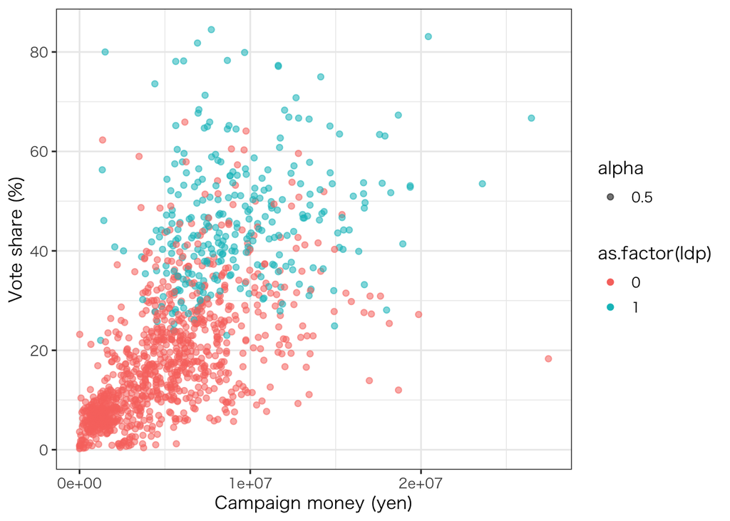

```r
plt_9 <- hr %>%
  filter(year == 2012) %>%
  mutate(ldp = ifelse(seito == "自民", 1, 0)) %>%
  ggplot() +
  geom_point(mapping = aes(x = exp,    # mapping = は省略可
y = voteshare,
alpha = 0.5,
color = as.factor(ldp))) +
  labs(x = "Campaign money (yen)", y = "Vote share (%)") +
  theme_bw(base_family = "HiraKakuProN-W3",
   base_size = 12)

plt_9
```

- Let’s change the color of dots by party affiliation from tomato and blue to different ones, such as `deeppink` and `aquamarine.`

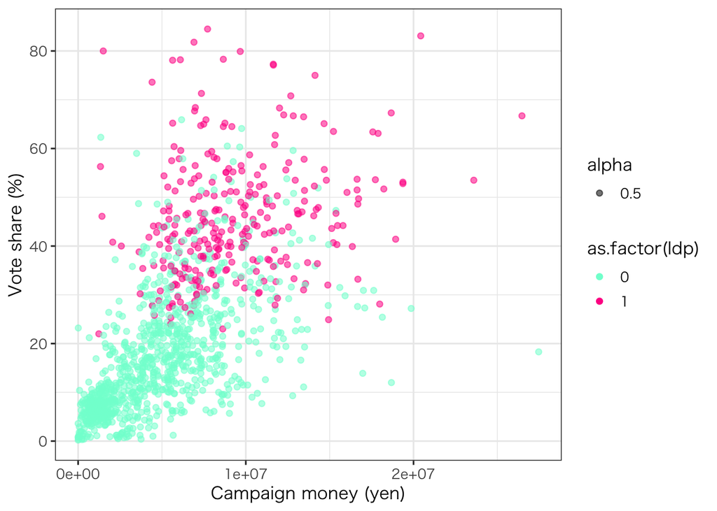

```r
plt_9 +
  scale_color_manual(values = c("1" = "deeppink", "0" = "aquamarine"))
```

## 6.6 Highlight

- You need to install and load a package, `{gghighlight}`

| **Elements** | **`{package}:function()`** | **What you can do** |
| --- | --- | --- |
| **7. Highlight** | `gghighlight()` | Emphasizing a particular data |

- Let’s draw a scatter plot using the 2005 HR election data:

・`x-axis` ・・・ expenditure (`exp`)  
・`y-axis` ・・・ vote share (`voteshare`)

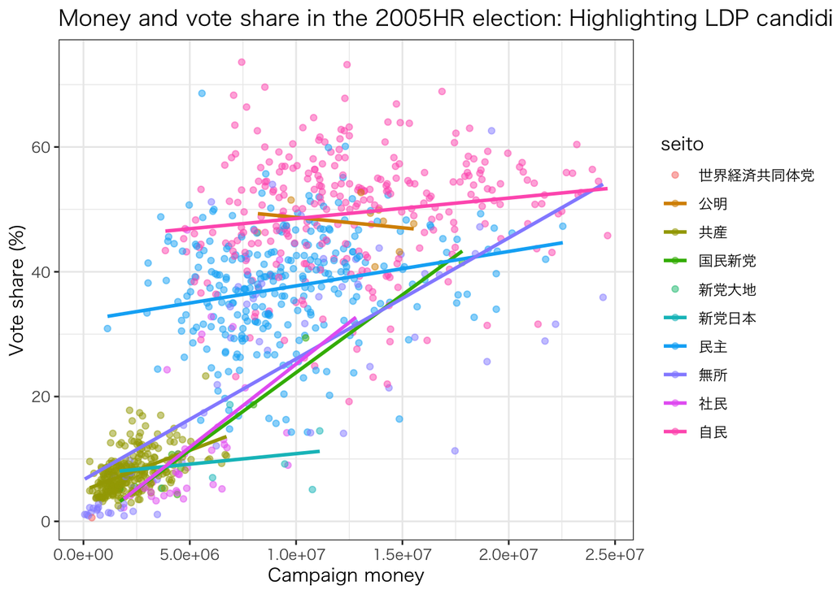

```r
plt_10 <- hr %>%
  select(seito, exp, voteshare, year) %>%
  filter(year == 2005) %>%
  ggplot(aes(x = exp,
y = voteshare,
col = seito)) +
  geom_point(alpha = 0.5) +
  labs(x = "Campaign money",
  y = "Vote share (%)",
  title = "Money and vote share in the 2005HR election: Highlighting LDP candididates") +
  geom_smooth(method = lm, se = FALSE) +
  theme_bw(base_family = "HiraKakuProN-W3")

plt_10
```

- Using `gghighlight()`, you can highlight a particular data
- Keep the other data as grey
- Emphasize the data you want to highlight in conspicuous colors

```r
library(gghighlight)
```

- Let’s emphasize the LDP and DPJ candidates in colors while the other candidates in grey

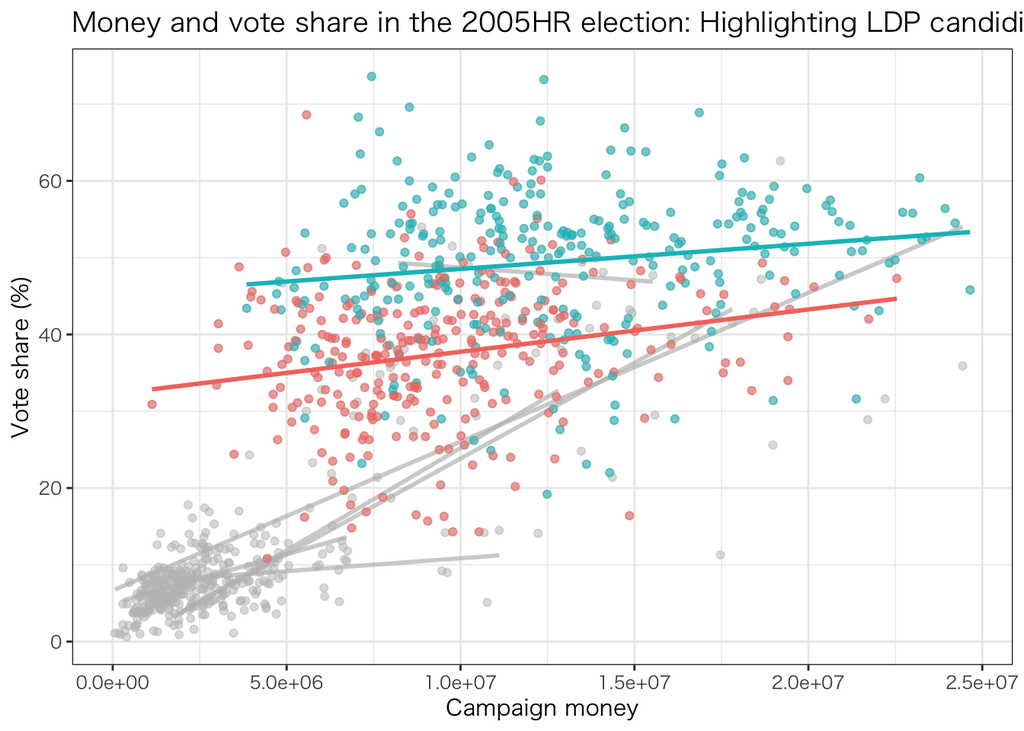

```r
plt_10 +
  gghighlight(seito == "自民" | seito == "民主")
```

## 6.7 Identifying dots

##### `{ggrepel}`

- You have the following two objectives to emphasize a particular data
1. You want to show **what is important** in a graph
2. You want to **compare multiple graphs**
- You cannot do this only with {`ggplot2`}  
  → You need to add additional package, `{ggrepel}`

| **Elements** | **`{package}:function()`** | **What you can do** |
| --- | --- | --- |
| **6. Identifying dots** | `{ggrepel}` | Identify what dots represent in scatter plot |

| **Elements** | **Function** |
| --- | --- |
| **`ggrepel_text_repel()`** | Adjust overlapping the values |
| **`ggrepel_label_repel()`** | Adjust overlapping the values |

- `geom_text_repel()` enables us to display values without overlapping
- Let’s put individual labels in the scatter plot we made with `df1`

```r
library(ggrepel)
```

#### If you want to display every single dot,…

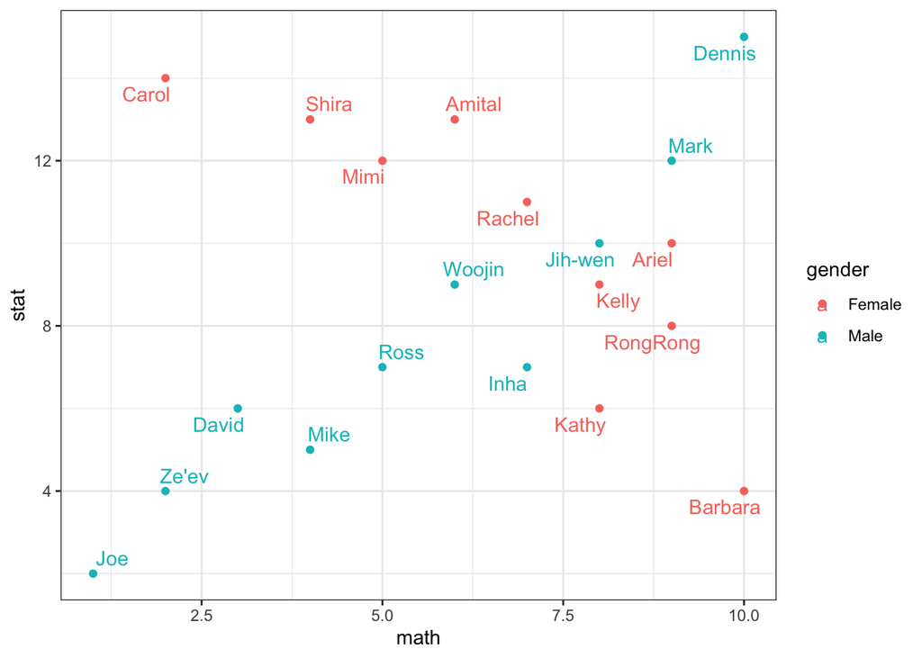

```r
plt_11 <- df1 %>%
  ggplot() +
  aes(math,
 stat,
 color = gender) +
  geom_point() +
  theme_bw()

plt_11 + geom_text_repel(aes(label = name))
```

- You can only display a particular data and pur labels on them

#### Display only top 5 people in math score

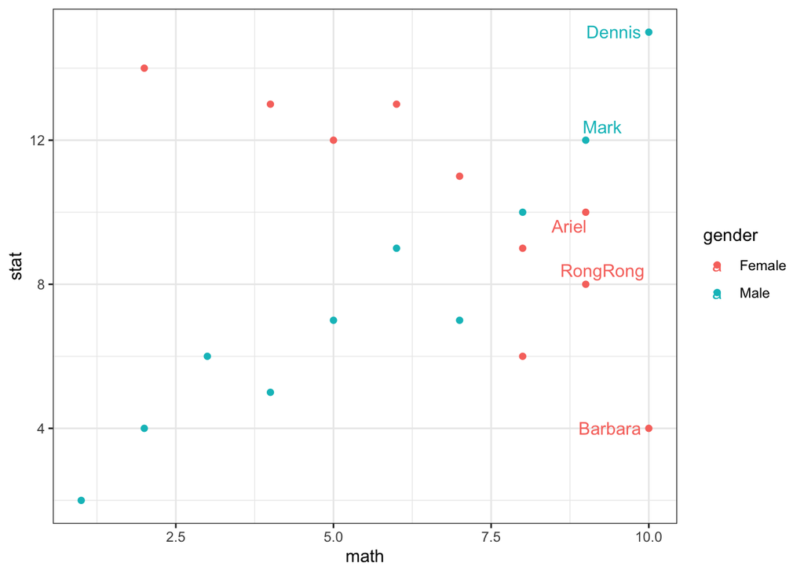

```r
plt_11 +
  geom_text_repel(aes(label = name),
    data = function(data)
 dplyr::slice_max(data,
 math,
 n = 5)
    )
```

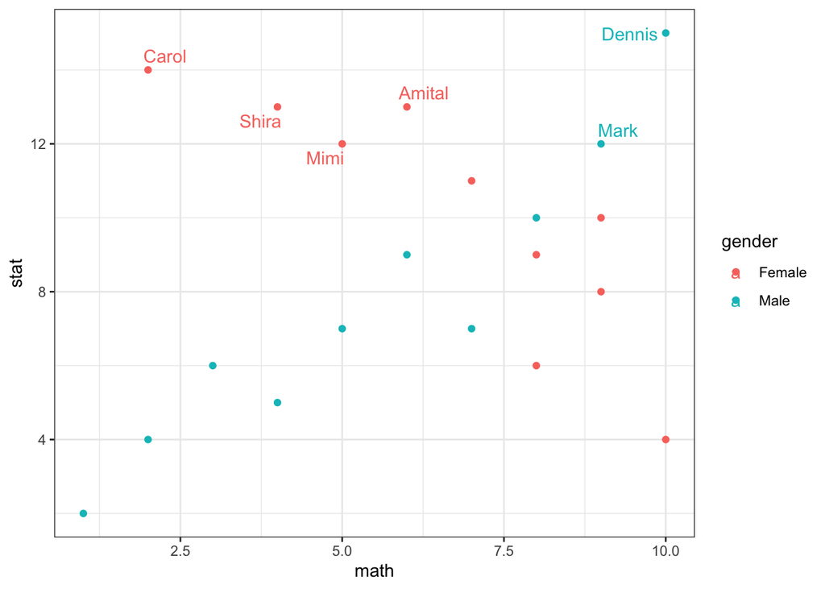

```r
plt_11 +
  geom_text_repel(aes(label = name),
    data = function(data)
 dplyr::filter(data,
 stat >= 12)
    )
```

```r
3^2 * 1 + 5 # when x = 1
```

```
[1] 14
```

```r
3^2 * 2 + 5 # when x = 2
```

```
[1] 23
```

・However, this way of calculation is extremely inefficient and very likely to face human errors.

##### A solution:

・ Make a `Sel-made function()` and use it.  
→ You can repeat the similar calculation efficiently with fewer errors

```r
f1 <- function(x){
  3^2 * x + 5
}
```

- Calculate the value when `x = 1`

```r
f1(x = 1)   # when x = 1
```

```
[1] 14
```

- Calculate the value when `x = 2`

```r
f1(x = 2)   # when x = 2
```

```
[1] 23
```

| **`f1()`** | The name of Function |
| --- | --- |
| **`x in function(x)`** | Argument |
| **`R code within {}`** | What `f1()` does |

- In R, a function is an object.  
  → If you plug in a variable, the function operates
- An argument `x` works as a variable within `{}`
- When the function operates, the value plugged in is executed.
- The R code within `{}` can be more than one line
- The last line in the R code can be used for the outcome

#### An Example of `Self-made function()`:

- Read the HR election data (1996-2021) in Japan

```r
hr <- read_csv("data/hr96-26.csv", na = ".")
```

- Draw the 2005 HR election data and name it `hr2005`

```r
hr2005 <- hr %>%
  filter(year == 2005)
```

- Check the variable names `hr2005` contains

```r
names(hr2005)
```

```
 [1] "year"          "pref"          "ku"            "kun"
 [5] "rank"          "wl"            "nocand"        "seito"
 [9] "j_name"        "name"          "previous"      "gender"
[13] "age"           "exp"           "status"        "vote"
[17] "voteshare"     "eligible"      "turnout"       "seshu_dummy"
[21] "jiban_seshu"   "nojiban_seshu"
```

- Make a self-made function to draw a box plot with a variable in `hr2005` and name the function `bp_hr2005`

```r
bp_hr2005 <- function(x){
  ggplot(hr2005) +
    aes(.data[[x]]) +
    geom_boxplot() +
    coord_flip()
}
```

What does `.data` mean? ・`.data` means a special variable the {`tidyverse`} has.  
・`.data` functions as an alias for the data frame under search.  
Example：  
・If you are working on the data frame, `hr2005`  
→ `hr2005[["age"]]` means `.data[["age"]]`  
・This means that **you select `age` from the data frame, `hr2005`**.

- Let’s try `age` on `x`

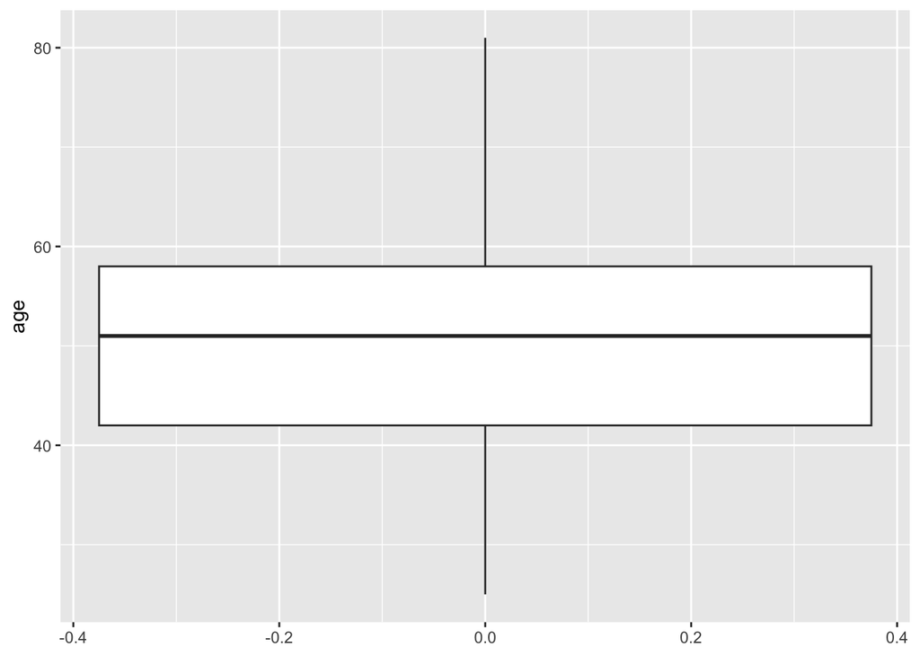

```r
bp_hr2005("age")
```

#### If you want to produce lots of graphs….

- By using `for()`, you can make your work more efficient.
- For instance, if you want to simultaneously make box plots on `age`, `voteshare` and `exp` and display their results…..

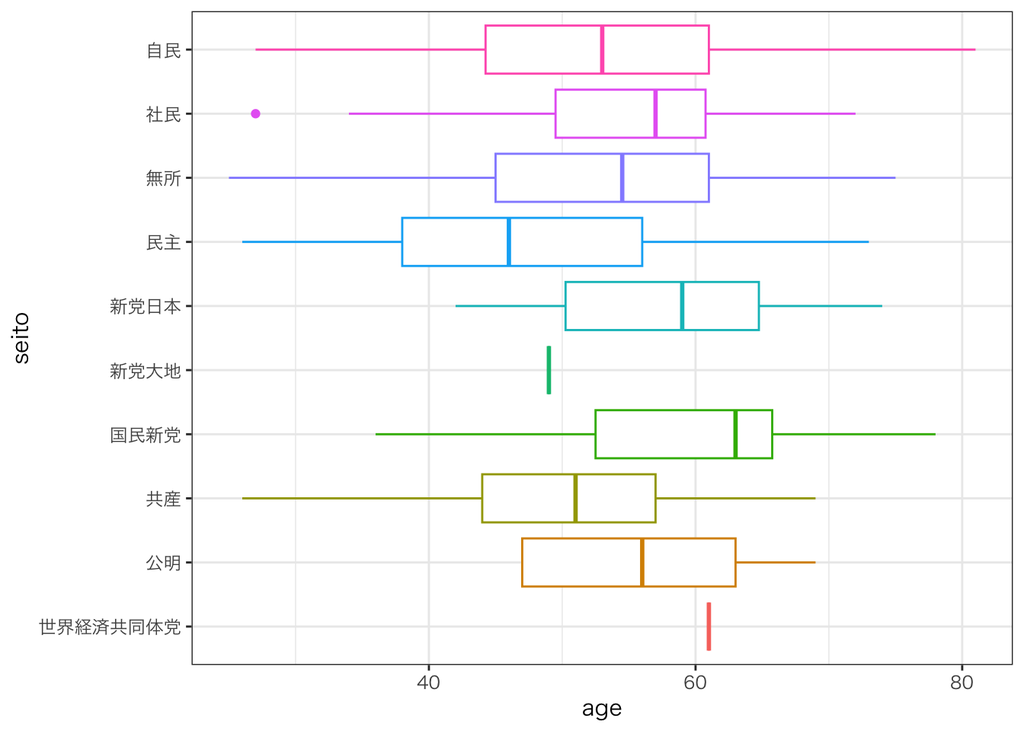

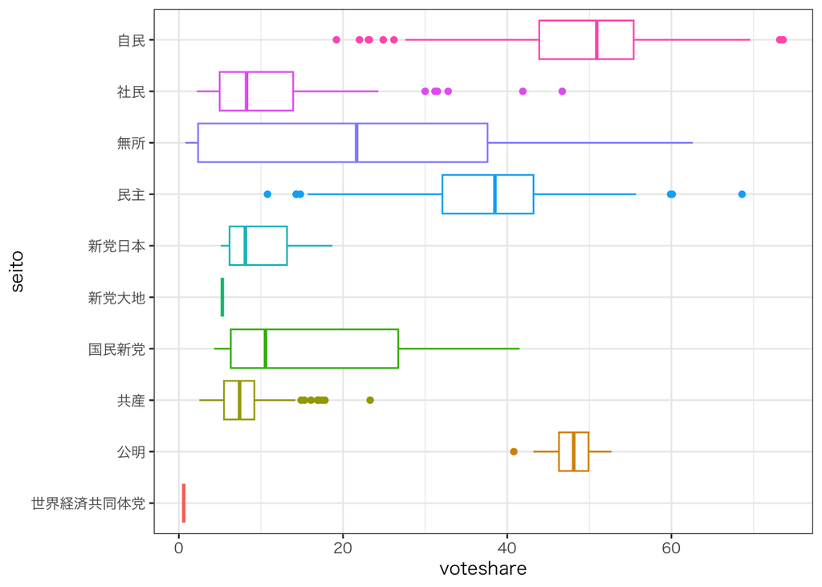

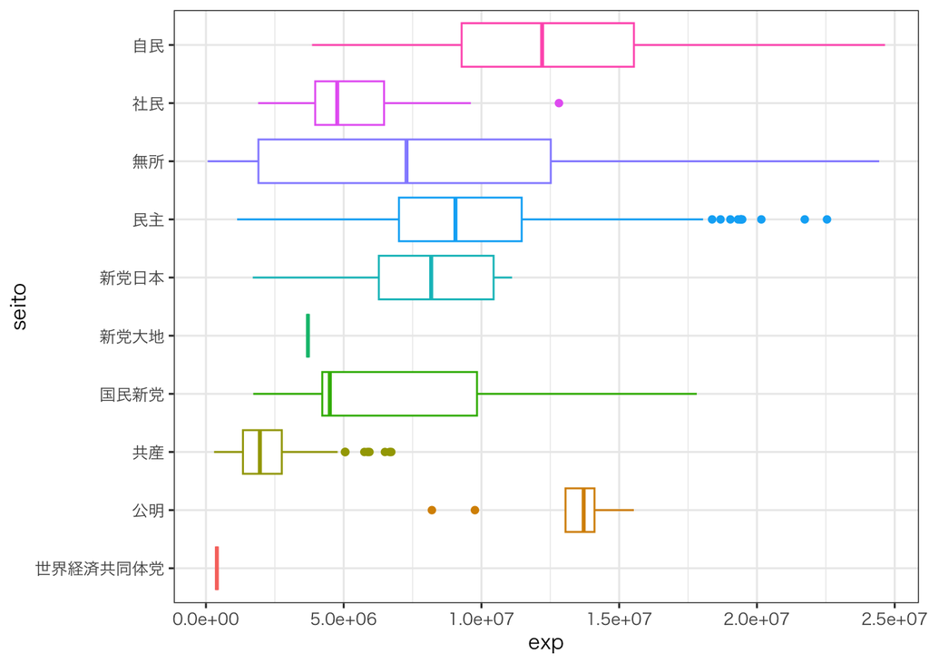

```r
bp_hr2005_1 <- function(x){
  ggplot(hr2005) +
    aes(x = .data[[x]],
y = .data[["seito"]],
color = .data[["seito"]]) +
    geom_boxplot() +
    theme_bw(base_family = "HiraKakuProN-W3") +
    theme(legend.position = "none")
}

for (x in c("age", "voteshare", "exp")){
  print(
    bp_hr2005_1(x)
  )
}
```

#### Combination of `highlight()` and `ggrepel_text_repel()`

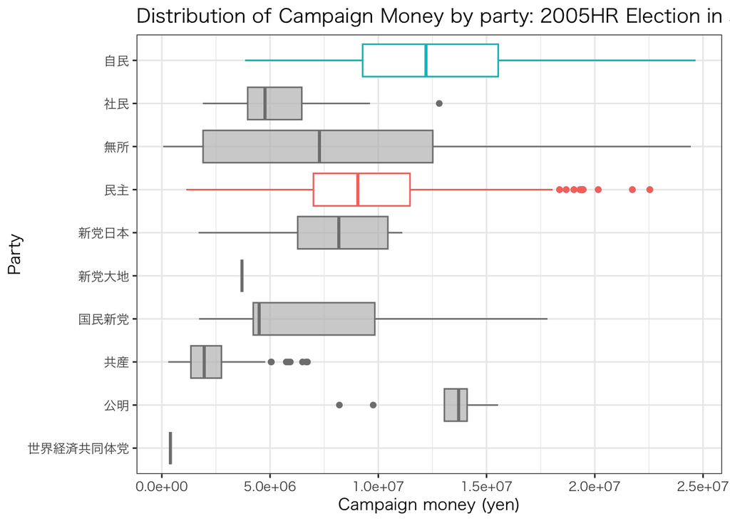

```r
# 散布図の作成
plt_13 <- hr2005 %>%
  ggplot() +
  aes(x = exp,
y = seito,
color = seito) +
  geom_boxplot() +
  theme_bw(base_family = "HiraKakuProN-W3") +
  theme(legend.position = "none") +
  labs(x = "Campaign money (yen)",
  y = "Party",
  title = "Distribution of Campaign Money by party: 2005HR Election in Japan")


plt_13 +
  gghighlight(seito == "自民" | seito == "民主",
label_key = seito,
unhighlighted_params = list(
  color = "grey50")
)
```

## 6.8 Facet

| **Elements** | **`{package}:function()`** | **What you can do** |
| --- | --- | --- |
| **8. Facet** | `facet_*()` | Making multiple graphs |

- You can make multiple graphs by levels of variable by using `facet()`
- Let’s make multiple scatter plots on campaign money and vote share by party in the 2005 HR election in Japan  
  ・ Read [`hr96-26.csv`](http://www.ner.takushoku-u.ac.jp/masano/class_material/waseda/keiryo/Data/hr96-26.csv)

```r
hr <- read_csv("data/hr96-26.csv", na = ".")
```

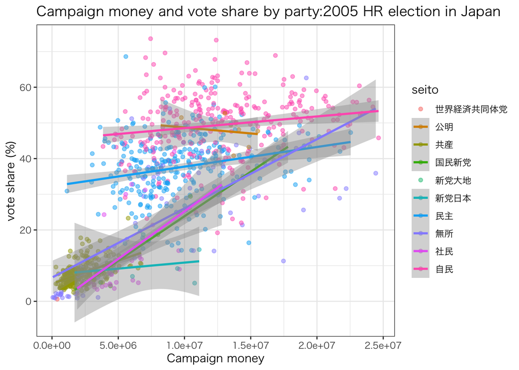

```r
plt_14 <- hr %>%
  select(seito, exp, voteshare, year) %>%
  filter(year == 2005) %>%  # Select the 2005 HR election data
  ggplot(aes(x = exp,
y = voteshare,
col = seito)) +
  geom_point(alpha = 0.5) +
  labs(x = "Campaign money", y = "vote share (%)") +
  geom_smooth(method = lm) +
  theme_bw(base_family = "HiraKakuProN-W3") +
  ggtitle("Campaign money and vote share by party:2005 HR election in Japan")

plt_14
```

- Adding `facet_wrap(~seito)`, you get the following multiple scatter plots by party

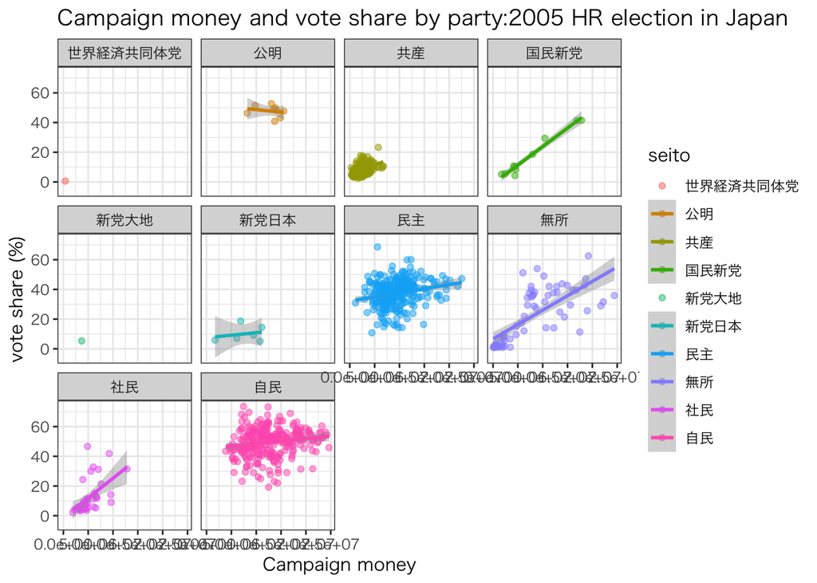

```r
plt_14 +
  facet_wrap(~seito) # Divide a scatter plot into several plots by party
```

- Within `facet()`, you can set the variable by which you change colors, the number of rows, and the number of colums

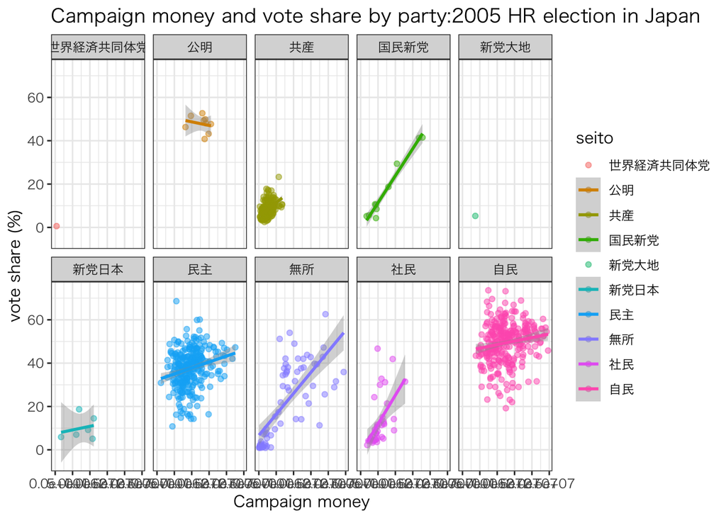

```r
plt_14 +
  facet_wrap(
    vars(seito), # set the variable
    nrow = 2,　 # set the number of rows
    ncol = 5　　# set the number of colums
  )
```

## 6.9 Patchwork

| **Elements** | **`{package}:function()`** | **What you can do** |
| --- | --- | --- |
| **9. Patchwork** | `{patchwork}` | Arranging multiple graphs |

- `{patchwork}` enables us to arrange different figures in one graph by using an operator ($|$ and $/$)
- You can also compare these multiple graphs

| **Operator** | **What you can do** |
| --- | --- |
| **`\|`** | Arrange in a row |
| **`/`** | Arrange in a column |

- For instance, you make multiple scatter plots with different colors  
  → You see whether there is an interaction between variables and how strong they are

### What we want to do here:

#### Check the relationship between campaign money and vote share by 3 variables in the 2005 HR election

1. LDP vs. non-LDP candidates
2. Gender
3. Candidate Status (Challenger, Incumbent, Non-incumbent)
- Define the function to get this done
- Name the function as `scatter_hr()` (whatever name you like)
- Using `patchwork::wrap_plots(nrow = 1)`, merge multiple results into one list to draw a graph

```r
library(patchwork)
```

- Read the HR election data

```r
hr <- read_csv("data/hr96-26.csv", na = ".")
```

- Draw the 2005 HR election data from `hr`, make LDP dummy (= 1 if a candidate is “自民”, 0 otherwise), and name the data frame as `hr2005`

```r
hr2005 <- hr %>%
  filter(year == 2005) %>%
  mutate(ldp = ifelse(seito == "自民", 1, 0))  # "自民" means "LDP" in Japanese
```

- Change class of the three variables (`status`, `gender`, `ldp`) to `factor`

```r
hr2005$status <- as.factor(hr2005$status)
hr2005$gender <- as.factor(hr2005$gender)
hr2005$ldp <- as.factor(hr2005$ldp)
```

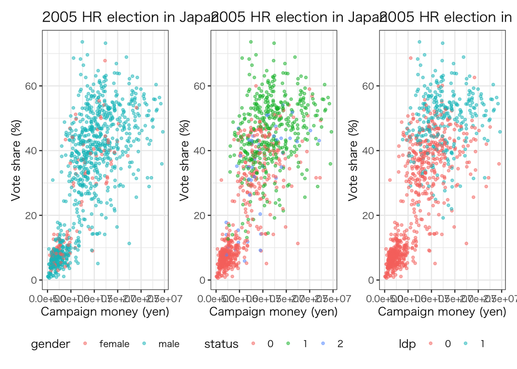

```r
# This is the function to draw a scatter plot of campaign money and vote share in the 2005 HR election

scatter_hr <- function(color = "seito"){ # Define scatter_hr()
  ggplot(hr2005) +
    aes(
 exp, voteshare,
 color = .data[[color]]
    ) +
    geom_point(size = 1, alpha = 0.5) +
    theme_bw(base_family = "HiraKakuProN-W3") +
    labs(x = "Campaign money (yen)",
 y = "Vote share (%)",
 title = "2005 HR election in Japan") +
    theme(legend.position = "bottom")
}

hr2005 %>%
  select(where(is.factor)) %>%
  names() %>%
  purrr::map(scatter_hr) %>%
  patchwork::wrap_plots(nrow = 1)
```

## 6.10 Interactive graph

| **Elements** | **`{package}:function()`** | **What you can do** |
| --- | --- | --- |
| **10. Interactive graph** | `{plotly}` | Making an interactive graph |

- `plotly::ggplotly()` enables us to explore the relationship used in a scatter plot made with `{ggplot2}`

・Read the HR election data

```r
hr <- read_csv("data/hr96-26.csv", na = ".")
```

- Draw the 2005 HR election data from `hr` and choose only winners and name it as `hr2005`

```r
hr2005 <- hr %>%
  filter(year == 2005) %>%
  filter(wl > 0)
```

- Make an interactive graph: plt_15

```r
library(ggplot2)
library(plotly)

plt_15 <- ggplot(hr2005,
  aes(x = exp,
    y = voteshare,
    color = seito)) +
  geom_point(alpha = 0.5) +
  theme_bw(base_family = "HiraKakuProN-W3")

ggplotly(plt_15)
```

[interactive chart not shown]

- You can see the 8 party names in Japanese on the right side legend
- If you click one of them, the dots corresponding to the party stops displaying on the scatter plot
- Click 6 party names except LDP (“自民”) and DPJ (“民主”)

[figure not shown]

- If you click the Camera icon below, then you can capture the graph you see and save it as `.png` file

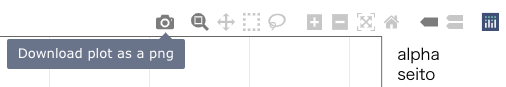

- If you want to save the scatter plot which only displays LDP and DPJ candidates, you can display it without using {`plotly`} as follow:

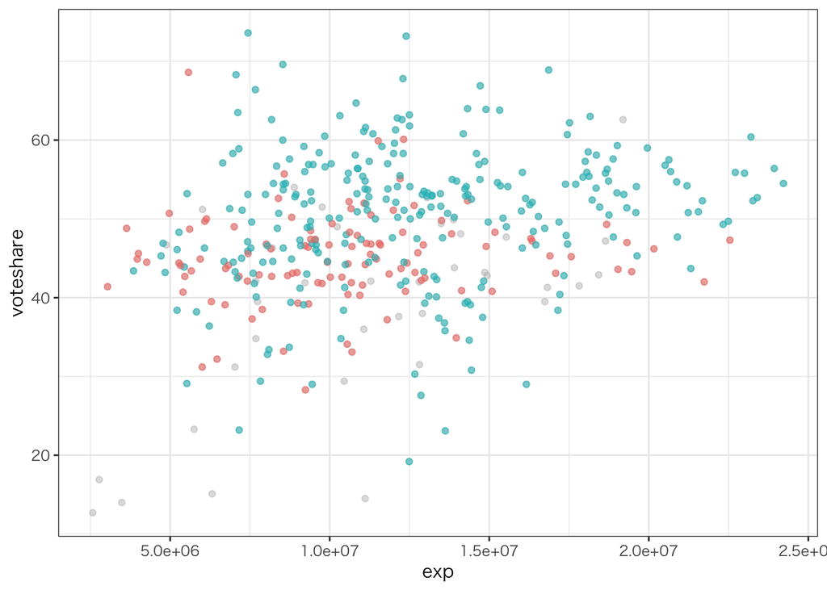

```r
plt_15 +
  gghighlight::gghighlight(seito == "民主" | seito == "自民")
```

## 6.11 Save a graph

- If you use `{plotly}`, you can capture a graph and save it.
- When you want save it with high a resolution, then use `ggsave()`
- Make a new folder in your R Project, and name it `fig` (whatever name you like)
- Save a graph you made in `fig` folder

```r
ggsave("fig/plt_15.png", # Name the file you want to save
  plt_15,                # Choose an object you made on RMarkdown
  width = 10,            # Set the width of the object
  height = 10,         　# Set the height of the object
  units = "cm")          # Set the unit of the size
                             # "in" or "cm
```

# 7. Variation in R code

- You can use various ways of R code
- For instance, suppose you want to use the following R code:

```r
ggplot(data = hr, mapping = aes(x = exp, y = voteshare))
```

- There are the other 9 ways of writing your R code:

| 1. `ggplot(hr, aes(x = exp, y = voteshare))` |
| --- |
| 2. `ggplot(hr, aes(exp, voteshare))` |
| 3. `ggplot(hr) + aes(x = exp, y = voteshare))` |
| 4. `ggplot(hr) + aes(exp, voteshare))` |
| **R code with pipe `%>%` (= `\|>`)** |
| 5. `hr %>% ggplot(mapping = aes(x = exp, y = voteshare))` |
| 6. `hr %>% ggplot(aes(x = exp, y = voteshare))` |
| 7. `hr %>% ggplot(aes(exp, voteshare))` |
| 8. `hr %>% ggplot() + aes(x = exp, y = voteshare))` |
| 9. `hr %>% ggplot() + aes(exp, voteshare))` |

# 8. Useful Websites on {`ggplot2`}

##### [ggplot2 extensions-gallery](https://exts.ggplot2.tidyverse.org/gallery/)

- This website visually show you what you can do with {ggplot2}

##### [from Data to vis](https://www.data-to-viz.com/)

- This web site shows how to visualize data not only on `R` but `Python` and `D3.js`

##### [TidyTuesday](https://github.com/rfordatascience/tidytuesday)

- Every week you see an updated quize on how to visalize data.
- Participants upload their R code in Twitter

# 9. CHEAT SHEET

- This cheat sheet is very useful

[figure not shown]

# 10. Exercise

・**Q10.1**: Reffering to `6.7 Identifying dots: Combination of highlight() and ggrepel_text_repel()`, draw a boxplot of campaign money (`exp`) in the 2009 HR election in Japan.

- In drawing your graph, see to highlight the LDP (“自民”) and the DPJ (“民主”) candidates
- Use [`hr96-26.csv`](http://www.ner.takushoku-u.ac.jp/masano/class_material/waseda/keiryo/Data/hr96-26.csv) in your analysis.

・**Q10.2**: Reffering to `6.6 Highlight`, draw a scatter plot of vote share (`voteshare`) in the 2009 HR election in Japan.

- In drawing your graph, see to highlight the LDP (“自民”) and the DPJ (“民主”) candidates
- Use [`hr96-26.csv`](http://www.ner.takushoku-u.ac.jp/masano/class_material/waseda/keiryo/Data/hr96-26.csv) in your analysis.

・**Q10.3**: Reffering to `6.8 Facet`, draw a scatter plot of campaign money (`exp`) and Vote share (`voteshare`) for the LDP (“自民”) and the DPJ (“民主”) in the 2009 HR election in Japan.

- In drawing your graph, use `facet_*()` and show the two regression lines for the LDP and the DPJ.

・**Q10.4**: Reffering to `6.7 Identifying dots: Self-made function()`, simultaneously draw multiple boxplots of `age`, `voteshare`, and `exp` for each party.

・**Q10.5**: Reffering to `6.9 Patchwork`, show how the relationship between campaign money (`exp`) and vote share (`voteshare`) changes in the 2009 HR election by `the DPJ vs. non-DPJ`, `gender`, and candidate status (`status`)

- In drawing your scatter plots, use `patchwork::wrap_plots().`

**Reference**

[宋財泫 (Jaehyun Song)・矢内勇生 (statuki statanai)「私たちのR: ベストプラクティスの探究」](https://www.jaysong.net/RBook/)

[宋財泫「可視化理論」](https://www.jaysong.net/tutorial/R/ggplot_intro1.html/)

[土井翔平（北海道大学公共政策大学院）「Rで計量政治学入門」](https://shohei-doi.github.io/quant_polisci/data-import.html)

[矢内勇生（高知工科大学）授業一覧](http://yukiyanai.github.io/teaching/)

浅野正彦, 矢内勇生.『Rによる計量政治学』オーム社、2018年

浅野正彦, 中村公亮.『初めてのRStudio』オーム社、2018年

Kieran Healy, DATA VISUALIZATION, Princeton, 2019

Kosuke Imai, Quantitative Social Science: An Introduction, Princeton University Press, 2017